# Week 3 Peer Review

Following the directions on the Coursera assignment page, you will make four original visualizations. Note that the data for the CCES and CEL data are imported in code in the R Markdown file.

### Put your name here: Mehwish Younus

## Exercise 1

Explain what you are visualizing here:

Here, I am visualing the number of total members in 115th congress distributed by their gender and stacked by power in the congress.

Put your figure here:

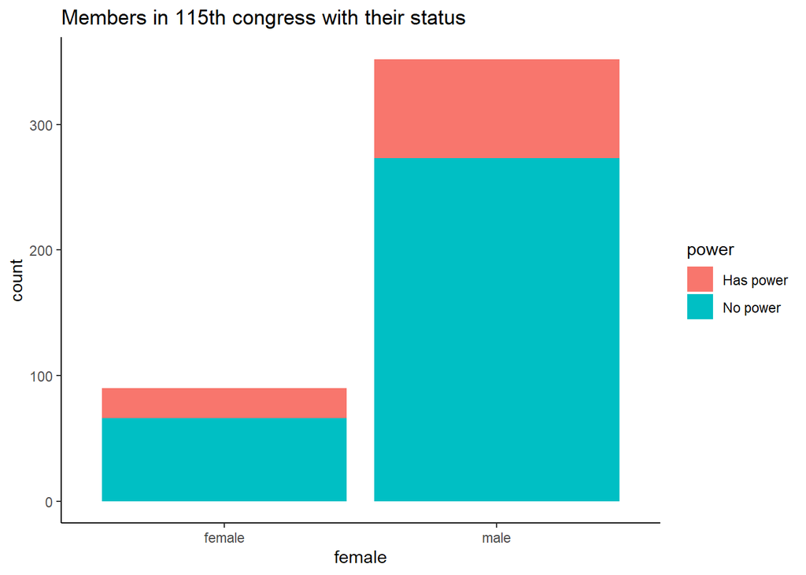

## Exercise 2

Explain what you are visualizing here:

I am visualizing the seniority status of member using a box plot. Whether a male has more experience or a female. There are a few outliers in male indicating that some males have more seniority than females.

Put your figure here:

```
##    Min. 1st Qu.  Median    Mean 3rd Qu.    Max.
##   1.000   2.000   4.000   5.517   8.000  27.000
```

```
##    Min. 1st Qu.  Median    Mean 3rd Qu.    Max.
##   1.000   2.000   3.500   5.478   7.750  18.000
```

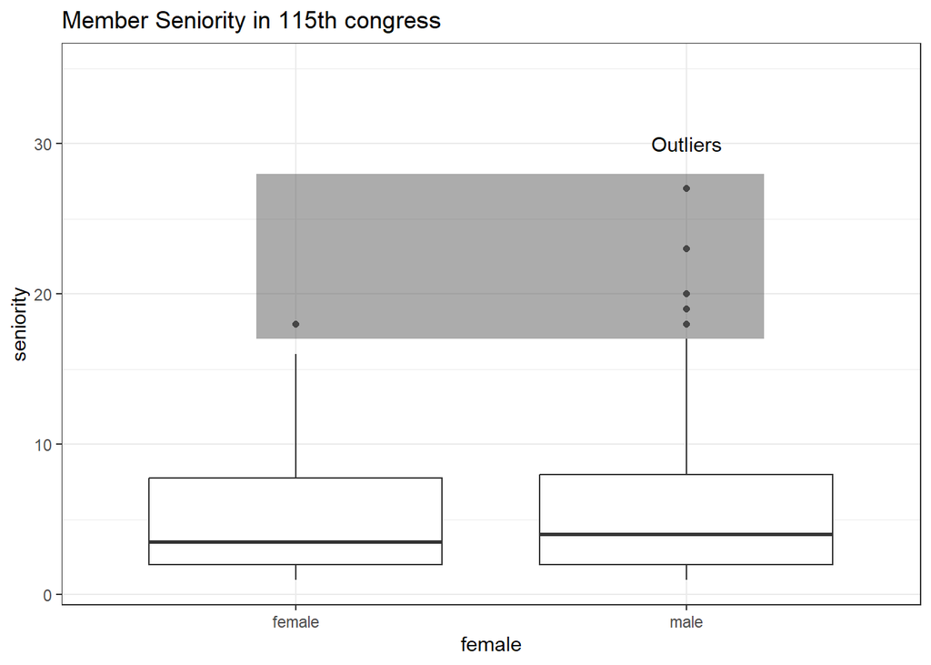

## Exercise 3

Explain what you are visualizing here:

I am trying to visualize how many bills were passed as member efficiency distributed by males and females. Republican party was able to pass more bills in both genders.

Put your figure here:

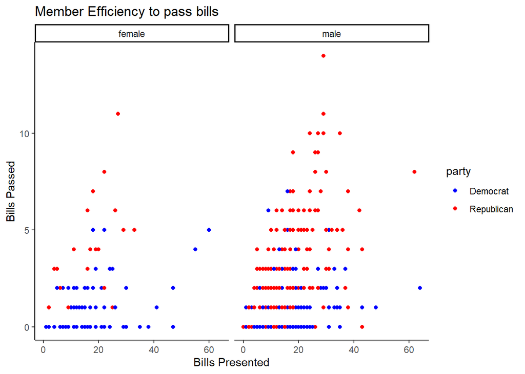

## Exercise 4

Explain what you are visualizing here:

I am trying to explain how the member ideology changes over time by distributing them into genders.

Put your figure here:

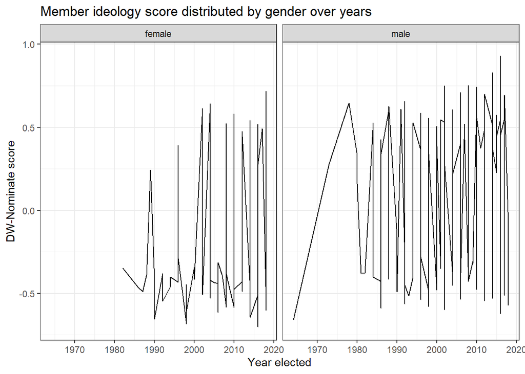